# ClonalOrigin sequential model and its summary statistics for SBI

```python
import numpy as np
import pandas as pd
import matplotlib.pyplot as plt
import seaborn as sns
from Bio import Phylo
import torch
from sbi.inference import NPE_C
from sbi.analysis import plot_summary
import sys
sys.path.append('../pysimARG')
from clonal_genealogy import ClonalTree
from newick_to_tree import newick_to_tree

torch_device = "cpu"
```

## Load simulation data

Load genome data and clonal tree.

```python
genome_simbac = np.loadtxt("../data/SimBac/genomes_bool.csv", delimiter=",", dtype=bool)
```

```python
genome_simbac.shape
```

```
(10, 100000)
```

```python
np.random.seed(100)
clonal_tree = ClonalTree(n=10)

# Load phylo tree and convert to ClonalTree format
phylo_tree = Phylo.read("../data/SimBac/clonal_frame.nwk", "newick")
Phylo.draw_ascii(phylo_tree)

edge, node_height = newick_to_tree(phylo_tree)
clonal_tree.edge = edge
clonal_tree.node_height = node_height
clonal_tree.height = np.max(node_height)
clonal_tree.length = np.sum(edge[:, 2])
```

```
                                                                   _______ 2
                                        __________________________|
                            ___________|                          |_______ 8
                           |           |
                           |           |___________________________________ 1
                        ___|                         _____________________ 6
                       |   |                       ,|
                       |   |                       ||  ___________________ 3
                       |   |                       ||_|
                       |   |_______________________|  |___________________ 9
  _____________________|                           |
 |                     |                           |         _____________ 5
 |                     |                           |________|
_|                     |                                    |_____________ 7
 |                     |
 |                     |__________________________________________________ 4
 |________________________________________________________________________ 0
```

## Summary statistics

This notebook evaluates the proportions and exact values of LD and G4 for comparison and selection. The items used in the summary statistics is listed below. Let $d$ denote the distance between sites in a pair, and $L$ denote the length of the gene segment.

1. $\text{LD}_{d < L/2}$
2. $\text{LD}_{d \geq L/2}$
3. $\# \text{G4}_{d < L/2}$
4. $\# \text{G4}_{d \geq L/2}$
5. $\frac{\text{LD}_{d < L/2}}{\# \text{segregating pairs that } d < L/2}$
6. $\frac{\text{LD}_{d \geq L/2}}{\# \text{segregating pairs that } d \geq L/2}$
7. $\frac{\# \text{G4}_{d < L/2}}{\# \text{segregating pairs that } d < L/2}$
8. $\frac{\# \text{G4}_{d \geq L/2}}{\# \text{segregating pairs that } d \geq L/2}$
9. $\text{LD}_{20 \leq d < 50}$
10. $\text{LD}_{50 \leq d \leq 80}$
11. $\# \text{G4}_{20 \leq d < 50}$
12. $\# \text{G4}_{50 \leq d \leq 80}$
13. $\frac{\text{LD}_{20 \leq d < 50}}{\# \text{segregating pairs that } 20 \leq d < 50}$
14. $\frac{\text{LD}_{50 \leq d \leq 80}}{\# \text{segregating pairs that } 50 \leq d \leq 80}$
15. $\frac{\# \text{G4}_{20 \leq d < 50}}{\# \text{segregating pairs that } 20 \leq d < 50}$
16. $\frac{\# \text{G4}_{50 \leq d \leq 80}}{\# \text{segregating pairs that } 50 \leq d \leq 80}$
17. homoplasy index based on the clonal structure
18. Proportion of segregating sites
19. $L$

### Get summary statistics from SimBac data

```python
x_500_mat = np.loadtxt("../data/x_500_mat.csv", delimiter=",")
x_2000_mat = np.loadtxt("../data/x_2000_mat.csv", delimiter=",")
x_6000_mat = np.loadtxt("../data/x_6000_mat.csv", delimiter=",")

x_o_500 = torch.tensor(x_500_mat[0, :], device=torch_device)
x_o_500 = x_o_500.to(torch.float32)

x_o_2000 = torch.tensor(x_2000_mat[0, :], device=torch_device)
x_o_2000 = x_o_2000.to(torch.float32)

x_o_6000 = torch.tensor(x_6000_mat[0, :], device=torch_device)
x_o_6000 = x_o_6000.to(torch.float32)
```

### Load simulations from ClonalOrigin model

```python
x_o_ClonalOrigin = np.loadtxt("../data/x_o_ClonalOrigin.csv", delimiter=",")

CO_x_500 = torch.tensor(x_o_ClonalOrigin[0, :], device=torch_device)
CO_x_500 = CO_x_500.to(torch.float32)

CO_x_2000 = torch.tensor(x_o_ClonalOrigin[1, :], device=torch_device)
CO_x_2000 = CO_x_2000.to(torch.float32)

CO_x_6000 = torch.tensor(x_o_ClonalOrigin[2, :], device=torch_device)
CO_x_6000 = CO_x_6000.to(torch.float32)
```

```python
theta1 = np.loadtxt('../data/theta1.csv', delimiter=",")
x1 = np.loadtxt('../data/x1.csv', delimiter=",")

theta2 = np.loadtxt('../data/theta2.csv', delimiter=",")
x2 = np.loadtxt('../data/x2.csv', delimiter=",")

x = np.vstack([x1, x2])
theta = np.vstack([theta1, theta2])

print(theta.shape, x.shape)
```

```
(10000, 3) (10000, 19)
```

```python
theta = torch.tensor(theta, device=torch_device)
theta = theta.to(torch.float32)
theta_numpy = theta.cpu().numpy()

x = torch.tensor(x, device=torch_device)
x = x.to(torch.float32)
x_numpy = x.cpu().numpy()
```

## NPE

### Using simulation of exact LD and G4 counts

```python
seed = 100
num_posterior_samples=1000
learning_rate = 0.0005

inference = NPE_C(density_estimator="nsf", device=torch_device)
torch.manual_seed(seed)
np.random.seed(seed)
```

```python
x1 = x[:, [0, 1, 2, 3, 8, 9, 10, 11, 16, 17, 18]]

x1.shape, x1.dtype
```

```
(torch.Size([10000, 11]), torch.float32)
```

```python
density_estimator1 = inference.append_simulations(theta, x1).train(
    max_num_epochs=500, learning_rate=learning_rate
)
posterior1 = inference.build_posterior(density_estimator1)
```

```
 Neural network successfully converged after 95 epochs.
```

```
For an interactive, detailed view of the summary, launch tensorboard  with 'tensorboard --logdir=c:\Users\u2008181\likelihood-free\python\sbi-logs\NPE_C\2026-05-15T11_41_11.893009' from a terminal on your machine, visit http://127.0.0.1:6006 afterwards. Requires port forwarding if tensorboard runs o…

Valid tags are: ['best_validation_loss', 'epoch_durations_sec', 'epochs_trained', 'training_loss', 'validation_loss'].
```

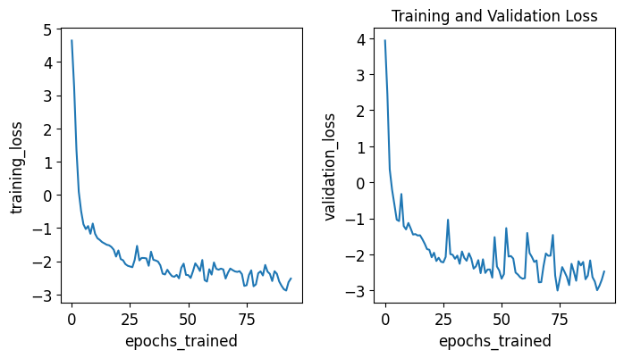

```python
fig, axes = plot_summary(
    inference,
    tags=["training_loss", "validation_loss"],
    figsize=(8, 4)
)
plt.title("Training and Validation Loss")
plt.show()
```

#### SimBac observations

```python
theta_trained_2000 = posterior1.set_default_x(x_o_2000[[0, 1, 2, 3, 8, 9, 10, 11, 16, 17, 18]]).sample((num_posterior_samples,), x=x_o_2000[[0, 1, 2, 3, 8, 9, 10, 11, 16, 17, 18]])
theta_trained_2000_numpy = theta_trained_2000.cpu().numpy()
```

```python
theta_trained_500 = posterior1.set_default_x(x_o_500[[0, 1, 2, 3, 8, 9, 10, 11, 16, 17, 18]]).sample((num_posterior_samples,), x=x_o_500[[0, 1, 2, 3, 8, 9, 10, 11, 16, 17, 18]])
theta_trained_500_numpy = theta_trained_500.cpu().numpy()
```

```python
theta_trained_6000 = posterior1.set_default_x(x_o_6000[[0, 1, 2, 3, 8, 9, 10, 11, 16, 17, 18]]).sample((num_posterior_samples,), x=x_o_6000[[0, 1, 2, 3, 8, 9, 10, 11, 16, 17, 18]])
theta_trained_6000_numpy = theta_trained_6000.cpu().numpy()
```

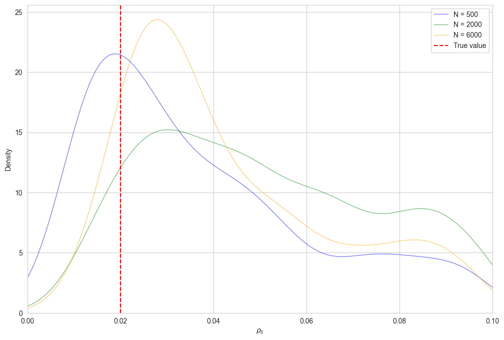

```python
plt.figure(figsize=(12, 8))
sns.set_style('whitegrid')
sns.kdeplot(theta_trained_500_numpy[:, 0], label='N = 500', color='blue', linewidth=1, alpha=0.5)
sns.kdeplot(theta_trained_2000_numpy[:, 0], label='N = 2000', color='green', linewidth=1, alpha=0.5)
sns.kdeplot(theta_trained_6000_numpy[:, 0], label='N = 6000', color='orange', linewidth=1, alpha=0.5)
plt.axvline(x=0.02, color='red', linestyle='dashed', label='True value')
plt.xlabel(r'$\rho_s$')
plt.xlim(0.0, 0.1)
plt.legend()
plt.show()
```

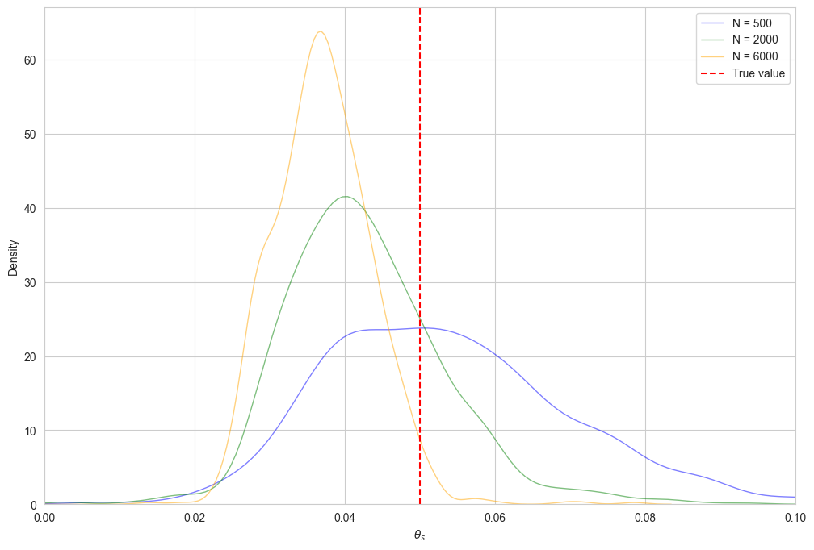

```python
plt.figure(figsize=(12, 8))
sns.set_style('whitegrid')
sns.kdeplot(theta_trained_500_numpy[:, 1], label='N = 500', color='blue', linewidth=1, alpha=0.5)
sns.kdeplot(theta_trained_2000_numpy[:, 1], label='N = 2000', color='green', linewidth=1, alpha=0.5)
sns.kdeplot(theta_trained_6000_numpy[:, 1], label='N = 6000', color='orange', linewidth=1, alpha=0.5)
plt.axvline(x=0.05, color='red', linestyle='dashed', label='True value')
plt.xlabel(r'$\theta_s$')
plt.xlim(0.0, 0.1)
plt.legend()
plt.show()
```

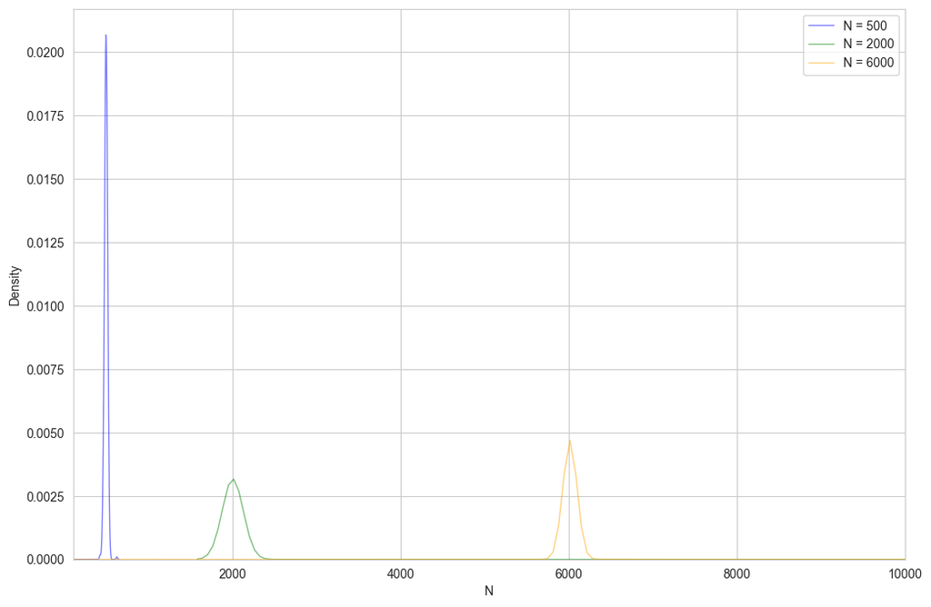

```python
plt.figure(figsize=(12, 8))
sns.set_style('whitegrid')
sns.kdeplot(theta_trained_500_numpy[:, 2], label='N = 500', color='blue', linewidth=1, alpha=0.5)
sns.kdeplot(theta_trained_2000_numpy[:, 2], label='N = 2000', color='green', linewidth=1, alpha=0.5)
sns.kdeplot(theta_trained_6000_numpy[:, 2], label='N = 6000', color='orange', linewidth=1, alpha=0.5)
plt.xlabel('N')
plt.xlim(100.0, 10000.0)
plt.legend()
plt.show()
```

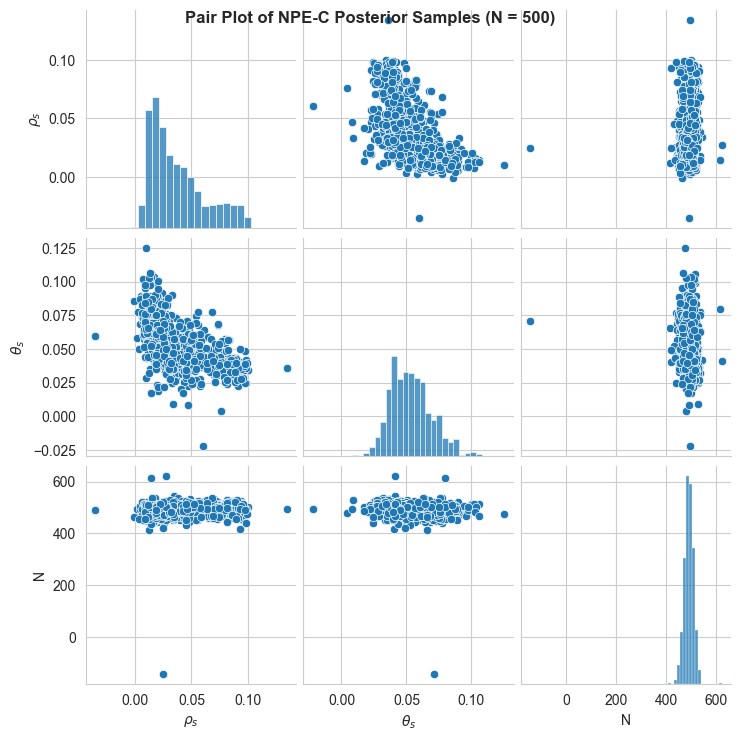

```python
df_500 = pd.DataFrame(theta_trained_500_numpy, columns=[r"$\rho_s$", r"$\theta_s$", "N"])
sns.pairplot(df_500)
plt.suptitle('Pair Plot of NPE-C Posterior Samples (N = 500)', fontsize=12, fontweight='bold')
plt.show()
```

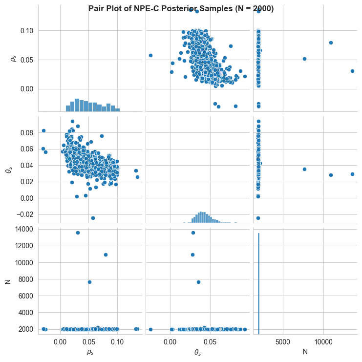

```python
df_2000 = pd.DataFrame(theta_trained_2000_numpy, columns=[r"$\rho_s$", r"$\theta_s$", "N"])
sns.pairplot(df_2000)
plt.suptitle('Pair Plot of NPE-C Posterior Samples (N = 2000)', fontsize=12, fontweight='bold')
plt.show()
```

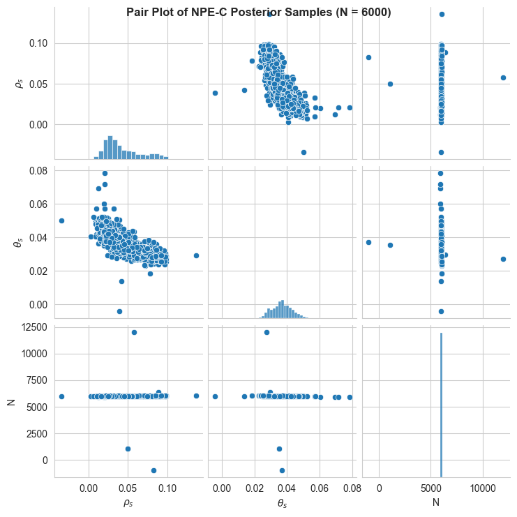

```python
df_6000 = pd.DataFrame(theta_trained_6000_numpy, columns=[r"$\rho_s$", r"$\theta_s$", "N"])
sns.pairplot(df_6000)
plt.suptitle('Pair Plot of NPE-C Posterior Samples (N = 6000)', fontsize=12, fontweight='bold')
plt.show()
```

#### ClonalOrigin observations

```python
theta_trained_2000 = posterior1.set_default_x(CO_x_2000[[0, 1, 2, 3, 8, 9, 10, 11, 16, 17, 18]]).sample((num_posterior_samples,), x=CO_x_2000[[0, 1, 2, 3, 8, 9, 10, 11, 16, 17, 18]])
theta_trained_2000_numpy = theta_trained_2000.cpu().numpy()
```

```python
theta_trained_500 = posterior1.set_default_x(CO_x_500[[0, 1, 2, 3, 8, 9, 10, 11, 16, 17, 18]]).sample((num_posterior_samples,), x=CO_x_500[[0, 1, 2, 3, 8, 9, 10, 11, 16, 17, 18]])
theta_trained_500_numpy = theta_trained_500.cpu().numpy()
```

```python
theta_trained_6000 = posterior1.set_default_x(CO_x_6000[[0, 1, 2, 3, 8, 9, 10, 11, 16, 17, 18]]).sample((num_posterior_samples,), x=CO_x_6000[[0, 1, 2, 3, 8, 9, 10, 11, 16, 17, 18]])
theta_trained_6000_numpy = theta_trained_6000.cpu().numpy()
```

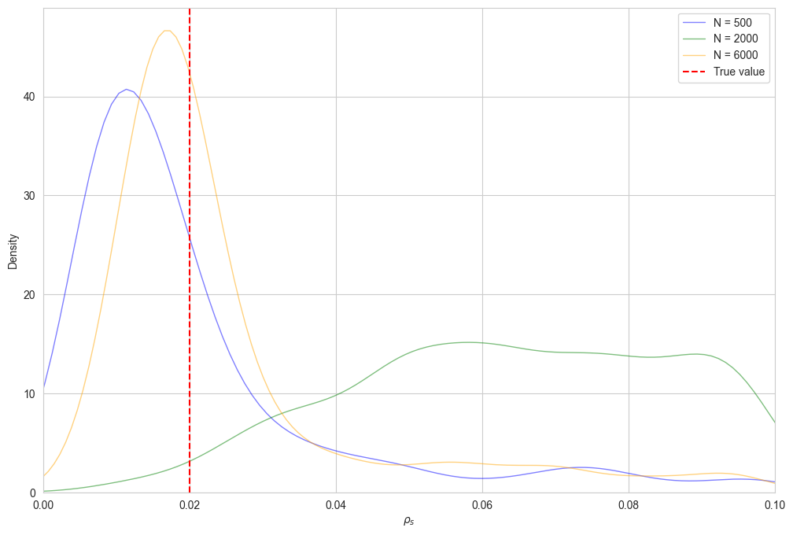

```python
plt.figure(figsize=(12, 8))
sns.set_style('whitegrid')
sns.kdeplot(theta_trained_500_numpy[:, 0], label='N = 500', color='blue', linewidth=1, alpha=0.5)
sns.kdeplot(theta_trained_2000_numpy[:, 0], label='N = 2000', color='green', linewidth=1, alpha=0.5)
sns.kdeplot(theta_trained_6000_numpy[:, 0], label='N = 6000', color='orange', linewidth=1, alpha=0.5)
plt.axvline(x=0.02, color='red', linestyle='dashed', label='True value')
plt.xlabel(r'$\rho_s$')
plt.xlim(0.0, 0.1)
plt.legend()
plt.show()
```

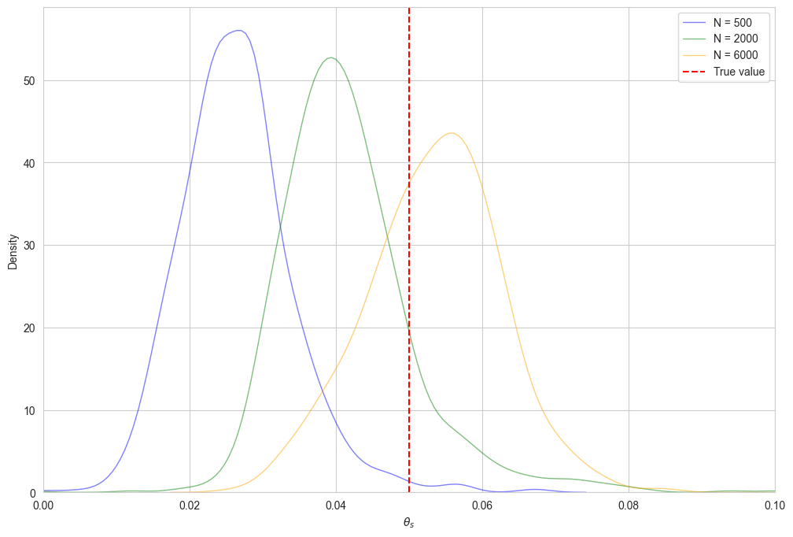

```python
plt.figure(figsize=(12, 8))
sns.set_style('whitegrid')
sns.kdeplot(theta_trained_500_numpy[:, 1], label='N = 500', color='blue', linewidth=1, alpha=0.5)
sns.kdeplot(theta_trained_2000_numpy[:, 1], label='N = 2000', color='green', linewidth=1, alpha=0.5)
sns.kdeplot(theta_trained_6000_numpy[:, 1], label='N = 6000', color='orange', linewidth=1, alpha=0.5)
plt.axvline(x=0.05, color='red', linestyle='dashed', label='True value')
plt.xlabel(r'$\theta_s$')
plt.xlim(0.0, 0.1)
plt.legend()
plt.show()
```

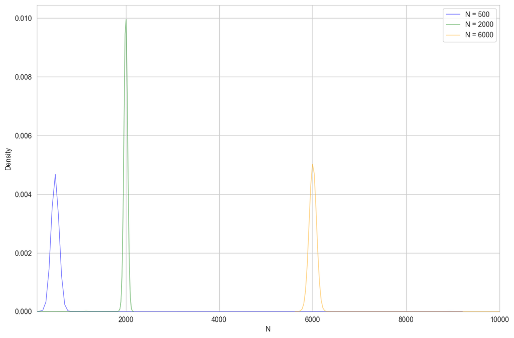

```python
plt.figure(figsize=(12, 8))
sns.set_style('whitegrid')
sns.kdeplot(theta_trained_500_numpy[:, 2], label='N = 500', color='blue', linewidth=1, alpha=0.5)
sns.kdeplot(theta_trained_2000_numpy[:, 2], label='N = 2000', color='green', linewidth=1, alpha=0.5)
sns.kdeplot(theta_trained_6000_numpy[:, 2], label='N = 6000', color='orange', linewidth=1, alpha=0.5)
plt.xlabel('N')
plt.xlim(100.0, 10000.0)
plt.legend()
plt.show()
```

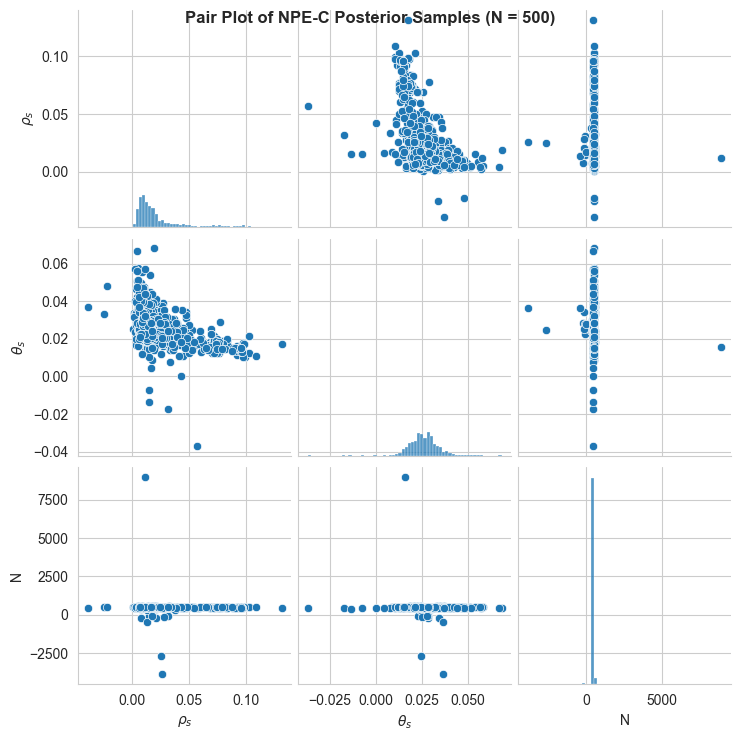

```python
df_500 = pd.DataFrame(theta_trained_500_numpy, columns=[r"$\rho_s$", r"$\theta_s$", "N"])
sns.pairplot(df_500)
plt.suptitle('Pair Plot of NPE-C Posterior Samples (N = 500)', fontsize=12, fontweight='bold')
plt.show()
```

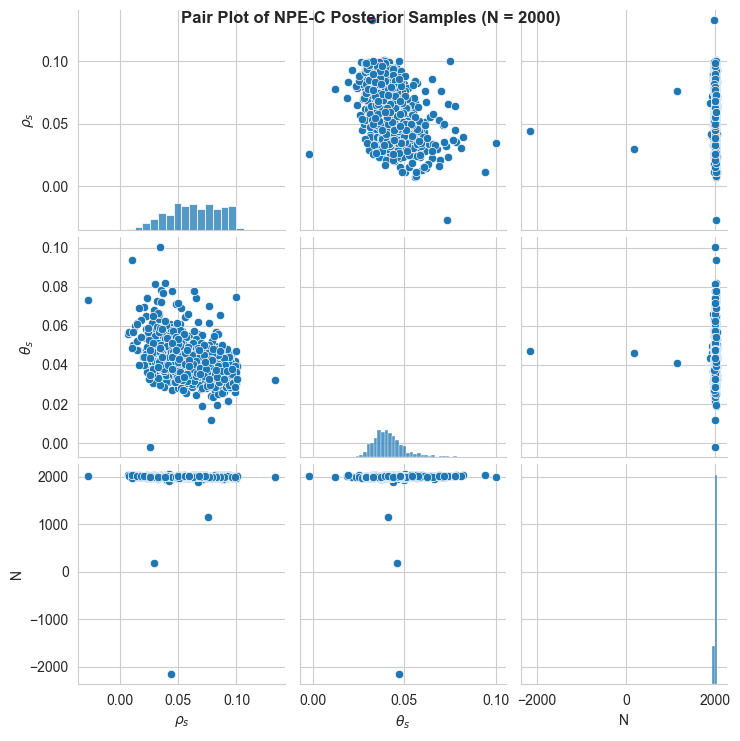

```python
df_2000 = pd.DataFrame(theta_trained_2000_numpy, columns=[r"$\rho_s$", r"$\theta_s$", "N"])
sns.pairplot(df_2000)
plt.suptitle('Pair Plot of NPE-C Posterior Samples (N = 2000)', fontsize=12, fontweight='bold')
plt.show()
```

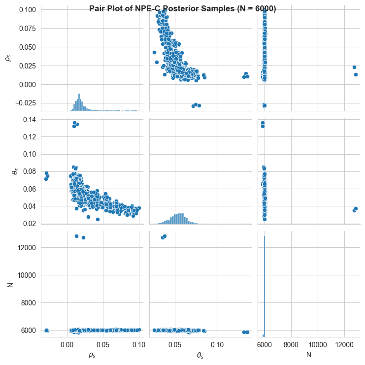

```python
df_6000 = pd.DataFrame(theta_trained_6000_numpy, columns=[r"$\rho_s$", r"$\theta_s$", "N"])
sns.pairplot(df_6000)
plt.suptitle('Pair Plot of NPE-C Posterior Samples (N = 6000)', fontsize=12, fontweight='bold')
plt.show()
```

### Using simulation of proportion values

```python
seed = 100
num_posterior_samples=1000
learning_rate = 0.0005

inference = NPE_C(density_estimator="nsf", device=torch_device)
torch.manual_seed(seed)
np.random.seed(seed)
```

```python
x2 = x[:, [4, 5, 6, 7, 12, 13, 14, 15, 16, 17, 18]]

x2.shape, x2.dtype
```

```
(torch.Size([10000, 11]), torch.float32)
```

```python
density_estimator2 = inference.append_simulations(theta, x2).train(
    max_num_epochs=500, learning_rate=learning_rate
)
posterior2 = inference.build_posterior(density_estimator2)
```

```
 Neural network successfully converged after 97 epochs.
```

```
For an interactive, detailed view of the summary, launch tensorboard  with 'tensorboard --logdir=c:\Users\u2008181\likelihood-free\python\sbi-logs\NPE_C\2026-05-15T11_44_04.271391' from a terminal on your machine, visit http://127.0.0.1:6006 afterwards. Requires port forwarding if tensorboard runs o…

Valid tags are: ['best_validation_loss', 'epoch_durations_sec', 'epochs_trained', 'training_loss', 'validation_loss'].
```

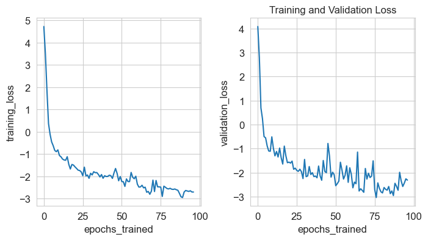

```python
fig, axes = plot_summary(
    inference,
    tags=["training_loss", "validation_loss"],
    figsize=(8, 4)
)
plt.title("Training and Validation Loss")
plt.show()
```

#### SimBac observations

```python
theta_trained_2000 = posterior2.set_default_x(x_o_2000[[4, 5, 6, 7, 12, 13, 14, 15, 16, 17, 18]]).sample((num_posterior_samples,), x=x_o_2000[[4, 5, 6, 7, 12, 13, 14, 15, 16, 17, 18]])
theta_trained_2000_numpy = theta_trained_2000.cpu().numpy()
```

```python
theta_trained_500 = posterior2.set_default_x(x_o_500[[4, 5, 6, 7, 12, 13, 14, 15, 16, 17, 18]]).sample((num_posterior_samples,), x=x_o_500[[4, 5, 6, 7, 12, 13, 14, 15, 16, 17, 18]])
theta_trained_500_numpy = theta_trained_500.cpu().numpy()
```

```python
theta_trained_6000 = posterior2.set_default_x(x_o_6000[[4, 5, 6, 7, 12, 13, 14, 15, 16, 17, 18]]).sample((num_posterior_samples,), x=x_o_6000[[4, 5, 6, 7, 12, 13, 14, 15, 16, 17, 18]])
theta_trained_6000_numpy = theta_trained_6000.cpu().numpy()
```

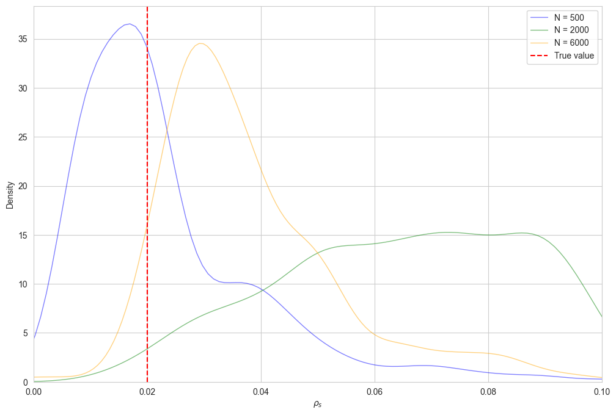

```python
plt.figure(figsize=(12, 8))
sns.set_style('whitegrid')
sns.kdeplot(theta_trained_500_numpy[:, 0], label='N = 500', color='blue', linewidth=1, alpha=0.5)
sns.kdeplot(theta_trained_2000_numpy[:, 0], label='N = 2000', color='green', linewidth=1, alpha=0.5)
sns.kdeplot(theta_trained_6000_numpy[:, 0], label='N = 6000', color='orange', linewidth=1, alpha=0.5)
plt.axvline(x=0.02, color='red', linestyle='dashed', label='True value')
plt.xlabel(r'$\rho_s$')
plt.xlim(0.0, 0.1)
plt.legend()
plt.show()
```

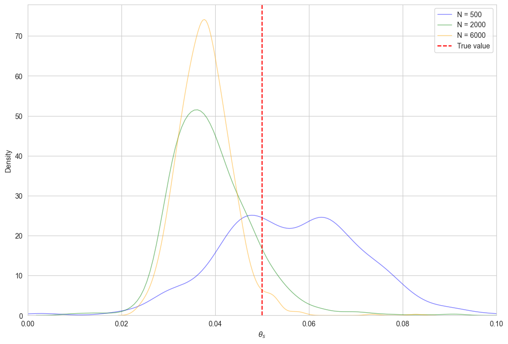

```python
plt.figure(figsize=(12, 8))
sns.set_style('whitegrid')
sns.kdeplot(theta_trained_500_numpy[:, 1], label='N = 500', color='blue', linewidth=1, alpha=0.5)
sns.kdeplot(theta_trained_2000_numpy[:, 1], label='N = 2000', color='green', linewidth=1, alpha=0.5)
sns.kdeplot(theta_trained_6000_numpy[:, 1], label='N = 6000', color='orange', linewidth=1, alpha=0.5)
plt.axvline(x=0.05, color='red', linestyle='dashed', label='True value')
plt.xlabel(r'$\theta_s$')
plt.xlim(0.0, 0.1)
plt.legend()
plt.show()
```

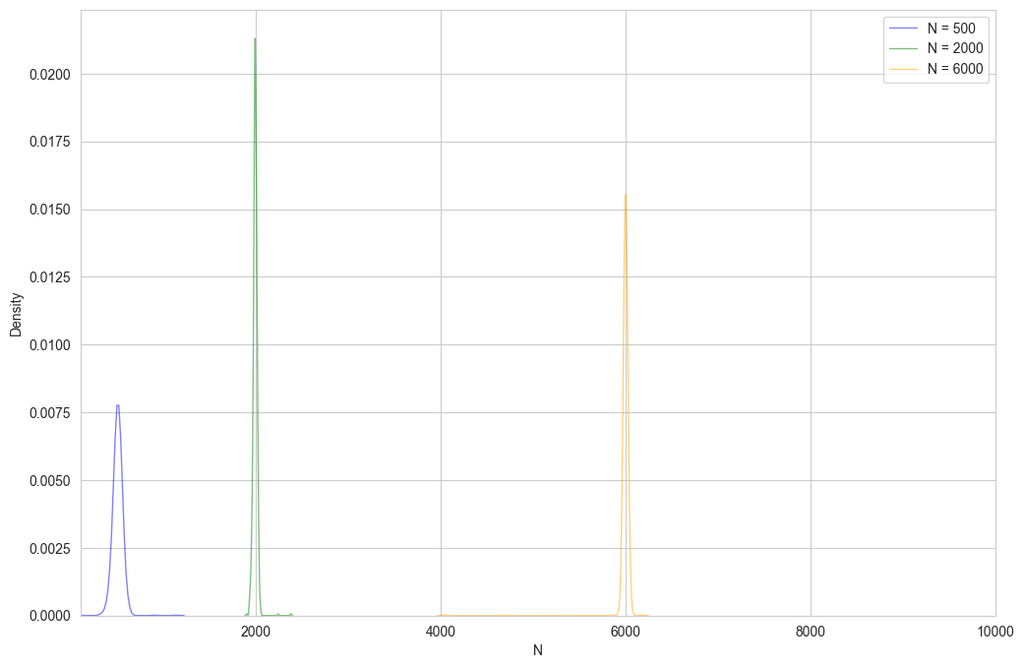

```python
plt.figure(figsize=(12, 8))
sns.set_style('whitegrid')
sns.kdeplot(theta_trained_500_numpy[:, 2], label='N = 500', color='blue', linewidth=1, alpha=0.5)
sns.kdeplot(theta_trained_2000_numpy[:, 2], label='N = 2000', color='green', linewidth=1, alpha=0.5)
sns.kdeplot(theta_trained_6000_numpy[:, 2], label='N = 6000', color='orange', linewidth=1, alpha=0.5)
plt.xlabel('N')
plt.xlim(100.0, 10000.0)
plt.legend()
plt.show()
```

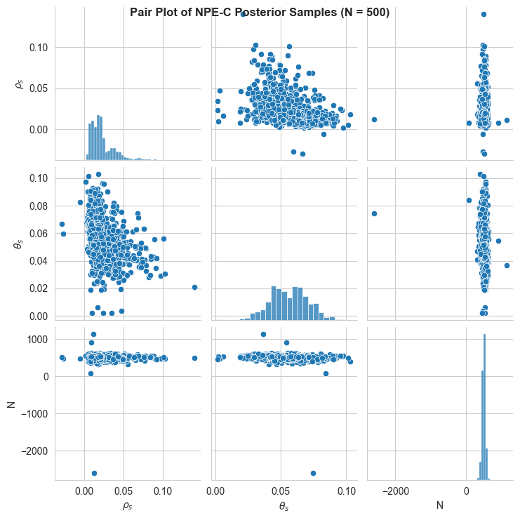

```python
df_500 = pd.DataFrame(theta_trained_500_numpy, columns=[r"$\rho_s$", r"$\theta_s$", "N"])
sns.pairplot(df_500)
plt.suptitle('Pair Plot of NPE-C Posterior Samples (N = 500)', fontsize=12, fontweight='bold')
plt.show()
```

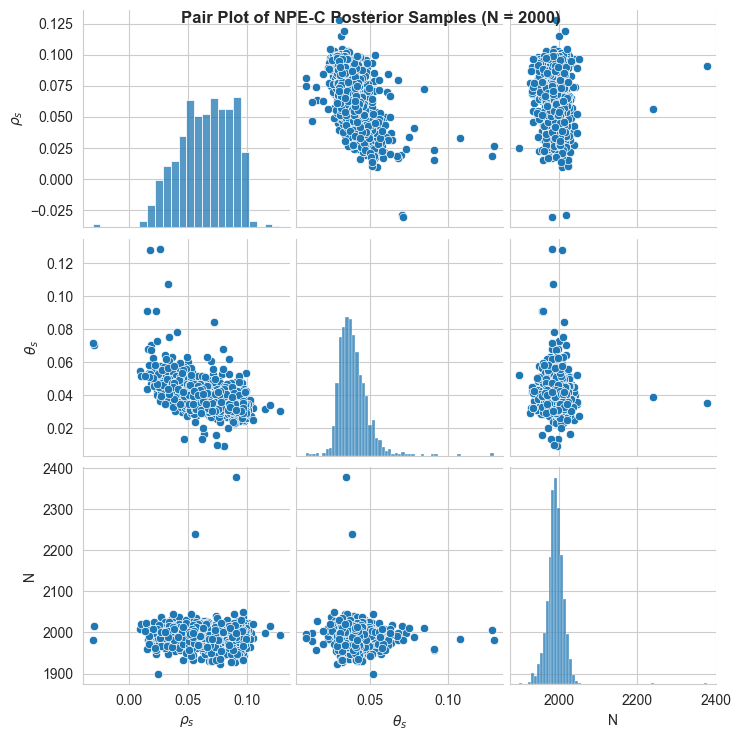

```python
df_2000 = pd.DataFrame(theta_trained_2000_numpy, columns=[r"$\rho_s$", r"$\theta_s$", "N"])
sns.pairplot(df_2000)
plt.suptitle('Pair Plot of NPE-C Posterior Samples (N = 2000)', fontsize=12, fontweight='bold')
plt.show()
```

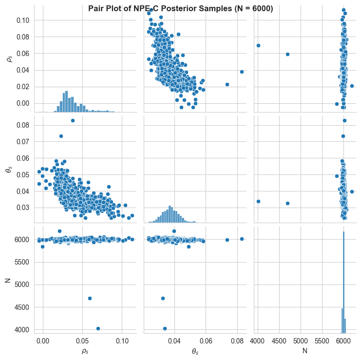

```python
df_6000 = pd.DataFrame(theta_trained_6000_numpy, columns=[r"$\rho_s$", r"$\theta_s$", "N"])
sns.pairplot(df_6000)
plt.suptitle('Pair Plot of NPE-C Posterior Samples (N = 6000)', fontsize=12, fontweight='bold')
plt.show()
```

#### ClonalOrigin observations

```python
theta_trained_2000 = posterior2.set_default_x(CO_x_2000[[4, 5, 6, 7, 12, 13, 14, 15, 16, 17, 18]]).sample((num_posterior_samples,), x=CO_x_2000[[4, 5, 6, 7, 12, 13, 14, 15, 16, 17, 18]])
theta_trained_2000_numpy = theta_trained_2000.cpu().numpy()
```

```python
theta_trained_500 = posterior2.set_default_x(CO_x_500[[4, 5, 6, 7, 12, 13, 14, 15, 16, 17, 18]]).sample((num_posterior_samples,), x=CO_x_500[[4, 5, 6, 7, 12, 13, 14, 15, 16, 17, 18]])
theta_trained_500_numpy = theta_trained_500.cpu().numpy()
```

```python
theta_trained_6000 = posterior2.set_default_x(CO_x_6000[[4, 5, 6, 7, 12, 13, 14, 15, 16, 17, 18]]).sample((num_posterior_samples,), x=CO_x_6000[[4, 5, 6, 7, 12, 13, 14, 15, 16, 17, 18]])
theta_trained_6000_numpy = theta_trained_6000.cpu().numpy()
```

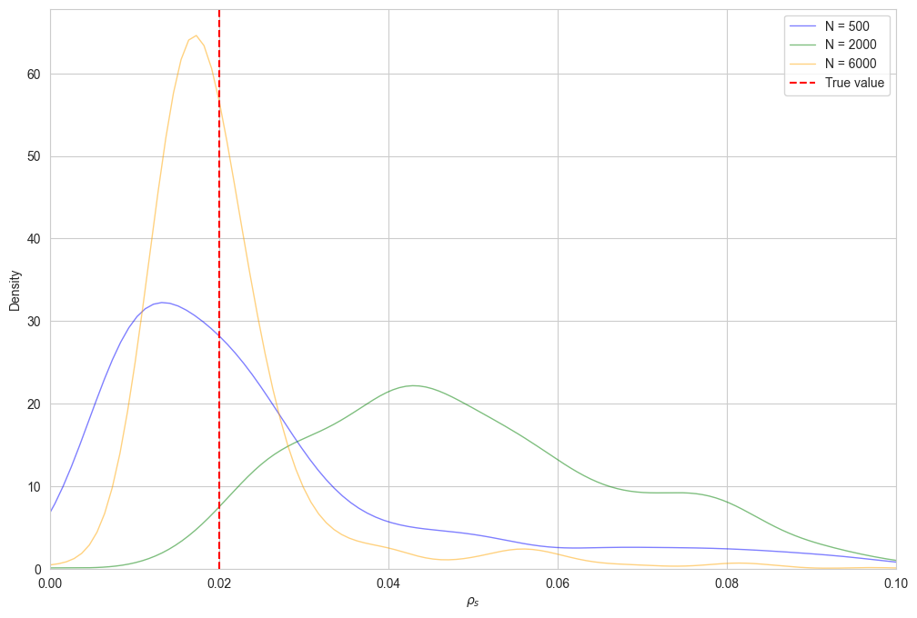

```python
plt.figure(figsize=(12, 8))
sns.set_style('whitegrid')
sns.kdeplot(theta_trained_500_numpy[:, 0], label='N = 500', color='blue', linewidth=1, alpha=0.5)
sns.kdeplot(theta_trained_2000_numpy[:, 0], label='N = 2000', color='green', linewidth=1, alpha=0.5)
sns.kdeplot(theta_trained_6000_numpy[:, 0], label='N = 6000', color='orange', linewidth=1, alpha=0.5)
plt.axvline(x=0.02, color='red', linestyle='dashed', label='True value')
plt.xlabel(r'$\rho_s$')
plt.xlim(0.0, 0.1)
plt.legend()
plt.show()
```

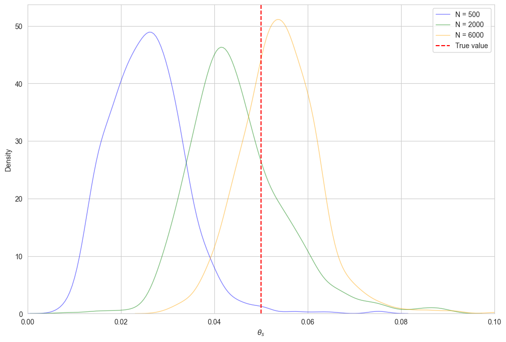

```python
plt.figure(figsize=(12, 8))
sns.set_style('whitegrid')
sns.kdeplot(theta_trained_500_numpy[:, 1], label='N = 500', color='blue', linewidth=1, alpha=0.5)
sns.kdeplot(theta_trained_2000_numpy[:, 1], label='N = 2000', color='green', linewidth=1, alpha=0.5)
sns.kdeplot(theta_trained_6000_numpy[:, 1], label='N = 6000', color='orange', linewidth=1, alpha=0.5)
plt.axvline(x=0.05, color='red', linestyle='dashed', label='True value')
plt.xlabel(r'$\theta_s$')
plt.xlim(0.0, 0.1)
plt.legend()
plt.show()
```

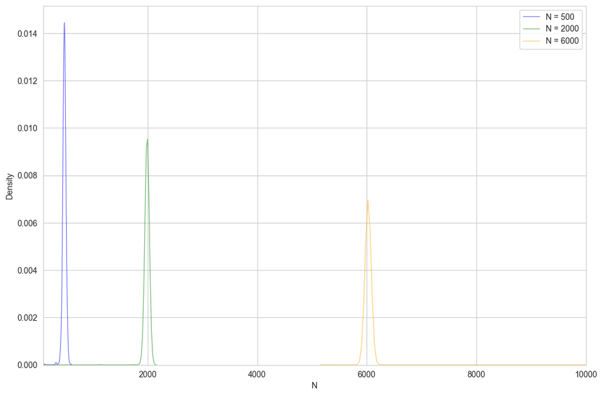

```python
plt.figure(figsize=(12, 8))
sns.set_style('whitegrid')
sns.kdeplot(theta_trained_500_numpy[:, 2], label='N = 500', color='blue', linewidth=1, alpha=0.5)
sns.kdeplot(theta_trained_2000_numpy[:, 2], label='N = 2000', color='green', linewidth=1, alpha=0.5)
sns.kdeplot(theta_trained_6000_numpy[:, 2], label='N = 6000', color='orange', linewidth=1, alpha=0.5)
plt.xlabel('N')
plt.xlim(100.0, 10000.0)
plt.legend()
plt.show()
```

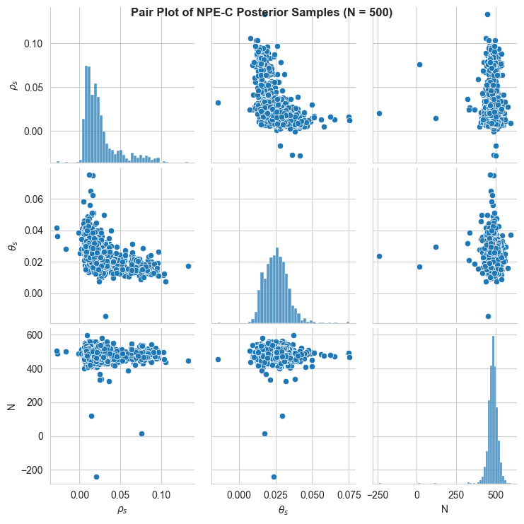

```python
df_500 = pd.DataFrame(theta_trained_500_numpy, columns=[r"$\rho_s$", r"$\theta_s$", "N"])
sns.pairplot(df_500)
plt.suptitle('Pair Plot of NPE-C Posterior Samples (N = 500)', fontsize=12, fontweight='bold')
plt.show()
```

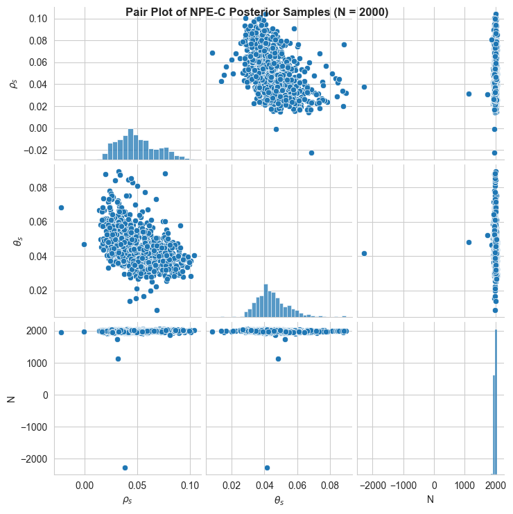

```python
df_2000 = pd.DataFrame(theta_trained_2000_numpy, columns=[r"$\rho_s$", r"$\theta_s$", "N"])
sns.pairplot(df_2000)
plt.suptitle('Pair Plot of NPE-C Posterior Samples (N = 2000)', fontsize=12, fontweight='bold')
plt.show()
```

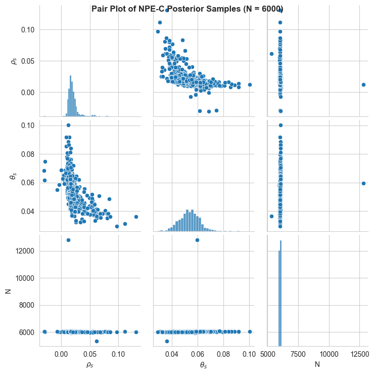

```python
df_6000 = pd.DataFrame(theta_trained_6000_numpy, columns=[r"$\rho_s$", r"$\theta_s$", "N"])
sns.pairplot(df_6000)
plt.suptitle('Pair Plot of NPE-C Posterior Samples (N = 6000)', fontsize=12, fontweight='bold')
plt.show()
```